# RUV-seq on polar infection

```r
knitr::opts_chunk$set(echo = TRUE)
knitr::opts_chunk$set(include = TRUE)
library(tidyverse)
library(greekLetters)
library(RUVSeq)
library(EDASeq)
library(DESeq2)
library(ggprism)
library(eulerr)
library(rcartocolor)
theme_set(theme_prism(base_size = 14))
```

```r
counts <- read.table(here::here("long_infection_human_reads/long_RNA_library/data/all_reads_STAR"), header = F, sep = "\t", stringsAsFactors = F)
#Next manipulate the table to remove redundant columns and only keep relevant columns (1 columns with gene names, and the rest with counts for reverse stranded library)
counts_simple <- counts %>%
  dplyr::select(Gene_ID = V1, UI92 = V4, UI93 = V8, UI96 = V12, N92 = V16, N93 = V20, WT96 = V24, WT91 = V28, WT94 = V32, N95 = V36)
#Filter really low expressed counts out
filter <- apply(counts_simple [,2:10],1,function(x) mean(x)>5)
counts_simple <- counts_simple [filter,]
```

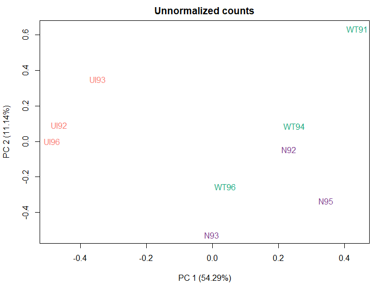

```r
#Use EDAseq to normalize the libraries
c_mat <- counts_simple %>%
                     dplyr::select(-where(is.character)) %>%
                     dplyr::slice(-1:-4) %>%
                     as.matrix()
rownames(c_mat) <- counts_simple$Gene_ID [-1:-4]
pData <- data.frame(genotype=vector(mode = "logical", length = ncol(c_mat)),
                    timepoint = vector(mode = "logical", length = ncol(c_mat)),
                    samples = colnames(c_mat),
                    row.names = colnames(c_mat))
pData <- pData %>%
  mutate(genotype = case_when(
    str_detect(samples, "WT") ~ "WT",
    str_detect(samples, "UI") ~ "UI",
    str_detect(samples, "N") ~ "N"
  ), timepoint = 9) %>%
  dplyr::select(-samples)
pData$group <- factor(paste0(pData$genotype,pData$timepoint))

data <- newSeqExpressionSet(counts=c_mat,
                            phenoData=pData)
#Normalize the data next
dataNorm <- betweenLaneNormalization(data, which="upper")
#For DE we will create this analysis with offset values
dataOffset <- betweenLaneNormalization(data,
                                       which="upper",offset=TRUE)
#Plot the counts
#pdf(here::here("long_infection_human_reads/long_RNA_library/results/final RUV figures/EDAseq_normalization.pdf"), width = 8, height = 6)
pal_choice <- "Bold"
pData <- pData %>%
  mutate(graph_cols  = case_when(
    genotype == "UI" ~ carto_pal(12,pal_choice) [10],
    genotype == "WT" ~ carto_pal(12,pal_choice) [2],
    genotype == "N" ~ carto_pal(12,pal_choice) [1]
  ))
plotPCA(data, col = pData$graph_cols, main = "Unnormalized counts")
```

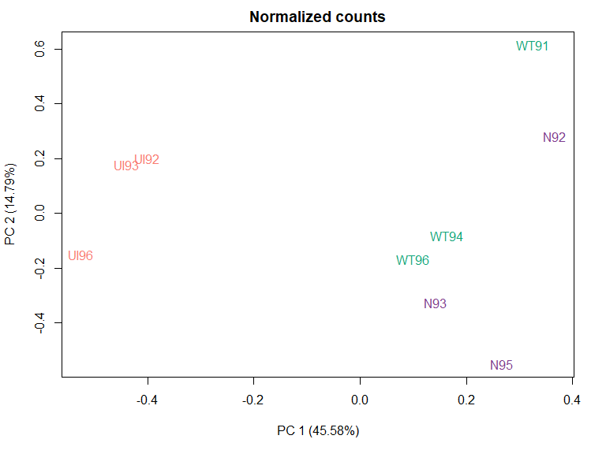

```r
plotPCA(dataOffset, col = pData$graph_cols, main = "Normalized counts")
```

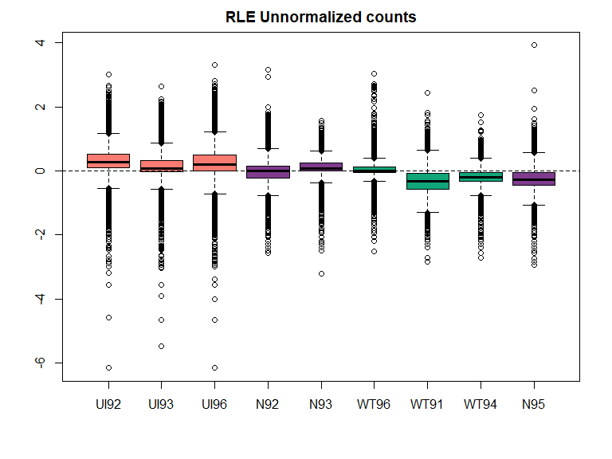

```r
plotRLE(data, col = pData$graph_cols, main = "RLE Unnormalized counts")
```

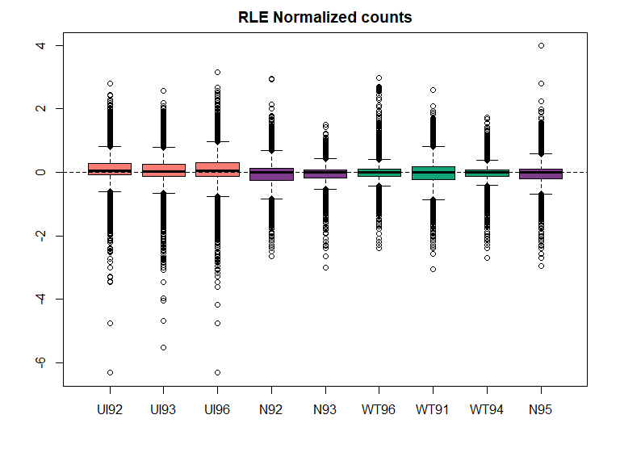

```r
plotRLE(dataOffset, col = pData$graph_cols, main = "RLE Normalized counts")
```

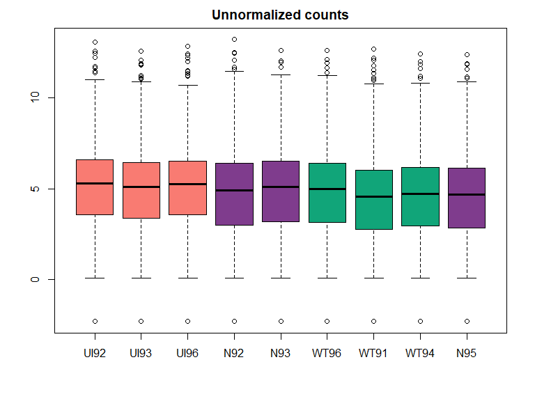

```r
boxplot(data, main = "Unnormalized counts", col = pData$graph_cols)
```

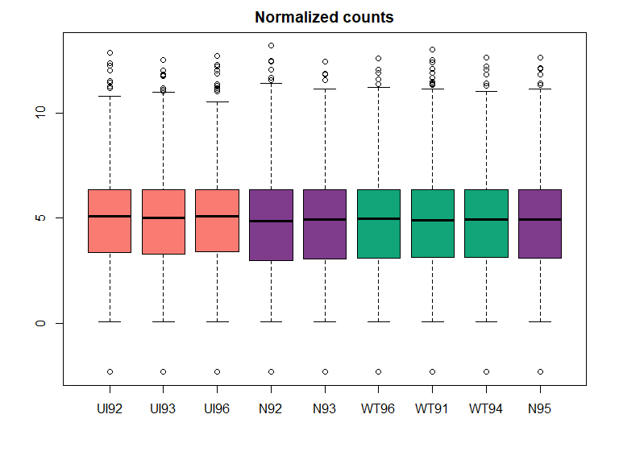

```r
boxplot(dataNorm, main = "Normalized counts", col = pData$graph_cols)
```

```r
#dev.off()
```

Try RUV-Seq. First confirm that library size normalization helps somewhat with data, but not enough for clear separation of genotypes

Prepare the RUV-seq objects and perform RUVs normalization

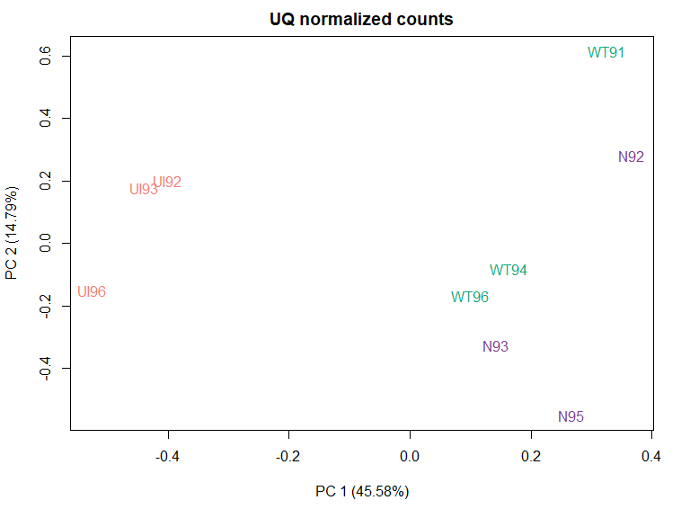

```r
scidx <- matrix(data = c(str_subset(rownames(pData), "UI"),
                         str_subset(rownames(pData), "WT"),
                         str_subset(rownames(pData), "N")),  nrow = 3, byrow = T)
cidx <- rownames(counts(data))
rv1 <- RUVs(dataOffset, cidx, k=1, scidx, epsilon = 1, isLog = F)
rv2 <- RUVs(dataOffset, cidx, k=2, scidx, epsilon = 1, isLog = F)
#pdf(here::here("long_infection_human_reads/long_RNA_library/results/final RUV figures/Normalization effect on the library and RUV normalization.pdf"), width = 8, height = 6)
plotPCA(dataOffset, col = pData$graph_cols, main = "UQ normalized counts")
```

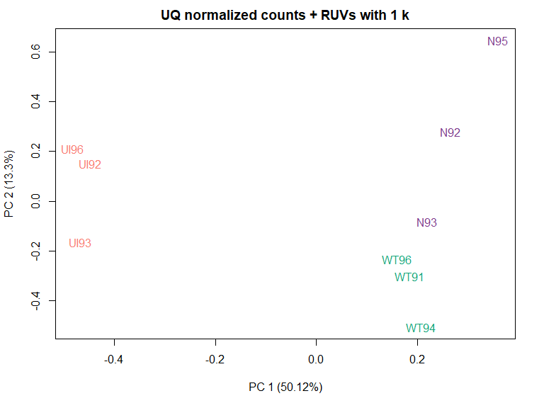

```r
plotPCA(rv1, col = pData$graph_cols, main = "UQ normalized counts + RUVs with 1 k")
```

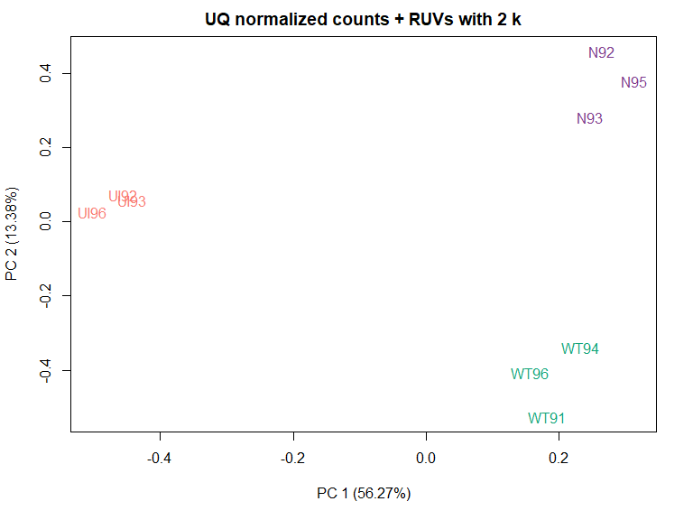

```r
plotPCA(rv2, col = pData$graph_cols, main = "UQ normalized counts + RUVs with 2 k")
```

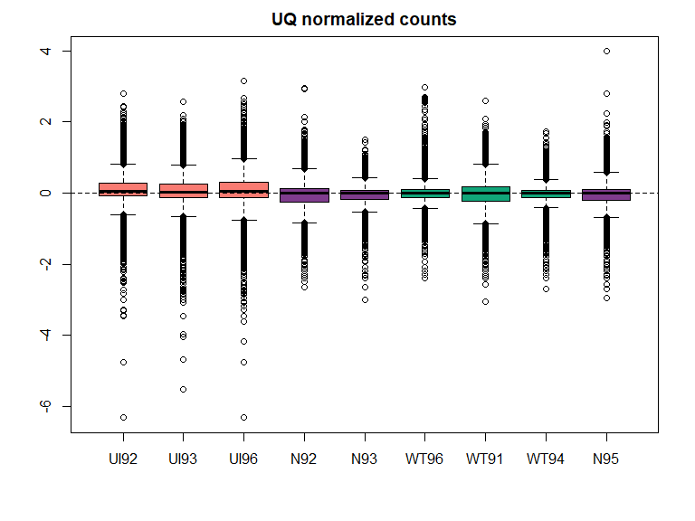

```r
plotRLE(dataOffset, col = pData$graph_cols, main = "UQ normalized counts")
```

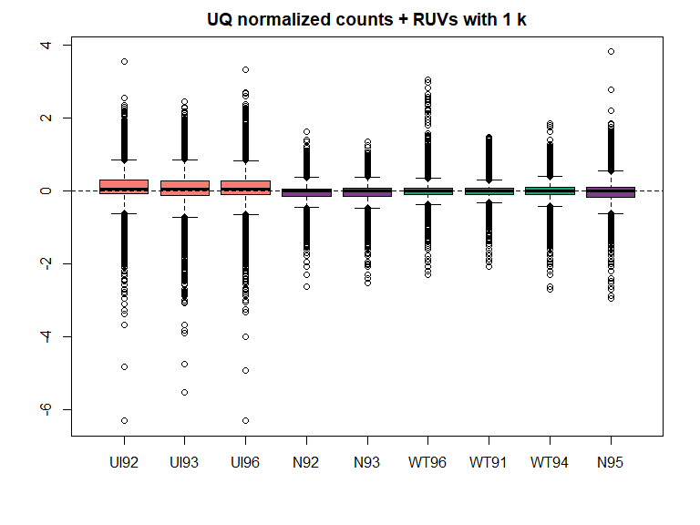

```r
plotRLE(rv1, col = pData$graph_cols, main = "UQ normalized counts + RUVs with 1 k")
```

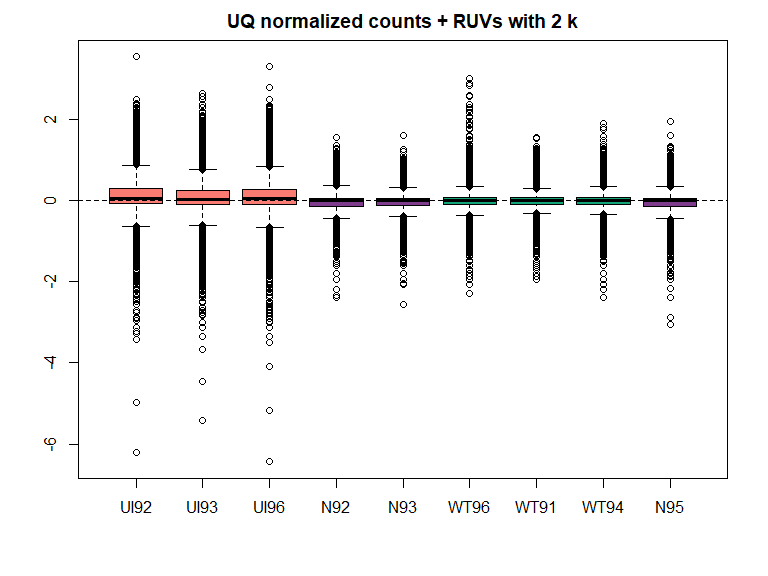

```r
plotRLE(rv2, col = pData$graph_cols, main = "UQ normalized counts + RUVs with 2 k")
```

```r
#dev.off()
```

#The RUV normalization is done, now we have normalization factors or weights, that can be fed into DESeq2 Keep an eye on this https://bioconductor.org/packages/release/workflows/vignettes/rnaseqGene/inst/doc/rnaseqGene.html#using-ruv-with-deseq2

```r
#Run differential expression analysis with just EDAseq normalization - and no RUV
dds <- DESeqDataSetFromMatrix(countData = counts(dataOffset),
                              colData = pData,
                              design = ~  group)
normFactors <- exp(-1 * offst(dataOffset))
normFactors <- normFactors / exp(rowMeans(log(normFactors)))
normalizationFactors(dds) <- normFactors
dds <- DESeq(dds)
```

using pre-existing normalization factors estimating dispersions gene-wise dispersion estimates mean-dispersion relationship final dispersion estimates fitting model and testing

```r
rld <- vst(dds)
DESeq2::plotPCA(rld, intgroup = "group")
```

```r
resWTvsUI <- results(dds, contrast = c("group","WT9", "UI9"))
resWTvsN <- results(dds, contrast = c("group","WT9", "N9"))
resNvsUI <- results(dds, contrast = c("group","N9", "UI9"))
map(list(resWTvsUI,resWTvsN,resNvsUI),summary)
```

out of 17401 with nonzero total read count adjusted p-value < 0.1 LFC > 0 (up) : 1224, 7% LFC < 0 (down) : 2507, 14% outliers [1] : 1, 0.0057% low counts [2] : 0, 0% (mean count < 5) [1] see ‘cooksCutoff’ argument of ?results [2] see ‘independentFiltering’ argument of ?results

out of 17401 with nonzero total read count adjusted p-value < 0.1 LFC > 0 (up) : 33, 0.19% LFC < 0 (down) : 19, 0.11% outliers [1] : 1, 0.0057% low counts [2] : 1687, 9.7% (mean count < 9) [1] see ‘cooksCutoff’ argument of ?results [2] see ‘independentFiltering’ argument of ?results

out of 17401 with nonzero total read count adjusted p-value < 0.1 LFC > 0 (up) : 1425, 8.2% LFC < 0 (down) : 3222, 19% outliers [1] : 1, 0.0057% low counts [2] : 0, 0% (mean count < 5) [1] see ‘cooksCutoff’ argument of ?results [2] see ‘independentFiltering’ argument of ?results

[[1]] NULL

[[2]] NULL

[[3]] NULL

```r
#Repeat analysis with RUVs and k=1
dds1 <- DESeqDataSetFromMatrix(countData = counts(rv1),
                              colData = pData(rv1),
                              design = ~ W_1 + group)
normFactors <- exp(-1 * offst(dataOffset))
normFactors <- normFactors / exp(rowMeans(log(normFactors)))
normalizationFactors(dds1) <- normFactors
dds1 <- DESeq(dds1)
```

using pre-existing normalization factors estimating dispersions gene-wise dispersion estimates mean-dispersion relationship final dispersion estimates fitting model and testing

```r
rld1 <- vst(dds1)
DESeq2::plotPCA(rld1, returnData = F, intgroup = "group")
```

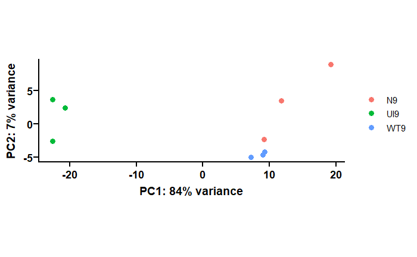

```r
#Use limma's removeBatchEffect for PCA plotting RUV-corrected data
mat <- limma::removeBatchEffect(assay(rld1),
                                covariates = rld1$W_1, design = model.matrix(~ genotype, colData(rld1)))
rld1.nobatch <- rld1
assay(rld1.nobatch) <- mat
DESeq2::plotPCA(rld1.nobatch, returnData = F, intgroup = "group")
```

```r
resWTvsUI.1 <- results(dds1, contrast = c("group","WT9", "UI9"))
resWTvsN.1 <- results(dds1, contrast = c("group","WT9", "N9"))
resNvsUI.1 <- results(dds1, contrast = c("group","N9", "UI9"))
map(list(resWTvsUI.1,resWTvsN.1,resNvsUI.1),summary)
```

out of 17401 with nonzero total read count adjusted p-value < 0.1 LFC > 0 (up) : 1289, 7.4% LFC < 0 (down) : 2427, 14% outliers [1] : 0, 0% low counts [2] : 0, 0% (mean count < 5) [1] see ‘cooksCutoff’ argument of ?results [2] see ‘independentFiltering’ argument of ?results

out of 17401 with nonzero total read count adjusted p-value < 0.1 LFC > 0 (up) : 141, 0.81% LFC < 0 (down) : 170, 0.98% outliers [1] : 0, 0% low counts [2] : 4049, 23% (mean count < 22) [1] see ‘cooksCutoff’ argument of ?results [2] see ‘independentFiltering’ argument of ?results

out of 17401 with nonzero total read count adjusted p-value < 0.1 LFC > 0 (up) : 1728, 9.9% LFC < 0 (down) : 3472, 20% outliers [1] : 0, 0% low counts [2] : 0, 0% (mean count < 5) [1] see ‘cooksCutoff’ argument of ?results [2] see ‘independentFiltering’ argument of ?results

[[1]] NULL

[[2]] NULL

[[3]] NULL

```r
#Now repeat with 2 factors accounted for:
dds2 <- DESeqDataSetFromMatrix(countData = counts(rv2),
                              colData = pData(rv2),
                              design = ~ W_1 + W_2 + group)
normalizationFactors(dds2) <- normFactors
dds2 <- DESeq(dds2)
```

using pre-existing normalization factors estimating dispersions gene-wise dispersion estimates mean-dispersion relationship final dispersion estimates fitting model and testing

```r
rld2 <- vst(dds2)
DESeq2::plotPCA(rld2, returnData = F, intgroup = "group")
```

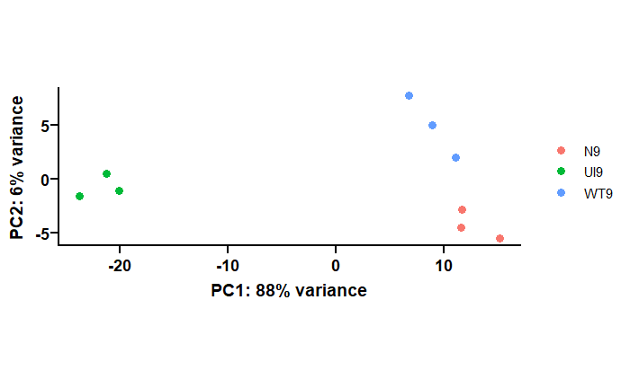

```r
mat <- limma::removeBatchEffect(assay(rld2),
                                covariates = matrix(data = c(rld2$W_1,rld2$W_2), ncol = 2),
                                design = model.matrix(~ genotype, colData(rld2)))
rld2.nobatch <- rld2
assay(rld2.nobatch) <- mat
DESeq2::plotPCA(rld2.nobatch, returnData = F, intgroup = "group")
```

```r
resWTvsUI.2 <- results(dds2, contrast = c("group","WT9", "UI9"))
resWTvsN.2 <- results(dds2, contrast = c("group","WT9", "N9"))
resNvsUI.2 <- results(dds2, contrast = c("group","N9", "UI9"))
walk(list(resWTvsUI.2,resWTvsN.2,resNvsUI.2),summary)
```

out of 17401 with nonzero total read count adjusted p-value < 0.1 LFC > 0 (up) : 1538, 8.8% LFC < 0 (down) : 2737, 16% outliers [1] : 0, 0% low counts [2] : 0, 0% (mean count < 5) [1] see ‘cooksCutoff’ argument of ?results [2] see ‘independentFiltering’ argument of ?results

out of 17401 with nonzero total read count adjusted p-value < 0.1 LFC > 0 (up) : 236, 1.4% LFC < 0 (down) : 254, 1.5% outliers [1] : 0, 0% low counts [2] : 4723, 27% (mean count < 29) [1] see ‘cooksCutoff’ argument of ?results [2] see ‘independentFiltering’ argument of ?results

out of 17401 with nonzero total read count adjusted p-value < 0.1 LFC > 0 (up) : 1802, 10% LFC < 0 (down) : 3619, 21% outliers [1] : 0, 0% low counts [2] : 0, 0% (mean count < 5) [1] see ‘cooksCutoff’ argument of ?results [2] see ‘independentFiltering’ argument of ?results

Generally, the differences between 1 and 2 factors are not that large. Check how differentially expressed genes behave

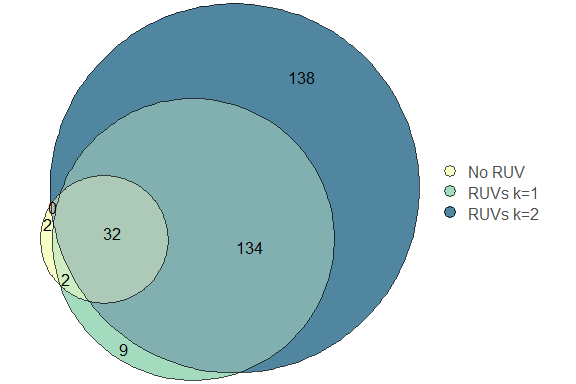

```r
wtvsn.res <- list(resWTvsN, resWTvsN.1,resWTvsN.2) %>%
  map(as.data.frame) %>%
  map(~(filter(.,padj < 0.05))) %>%
  map(function(x) rownames(x))
names(wtvsn.res) <- c("No RUV","RUVs k=1","RUVs k=2")
#Visualize these results on a Venn diagram
#pdf(here::here("long_infection_human_reads/long_RNA_library/results/final RUV figures/RUV effect on DE genes between WT and EscN infection.pdf"), width = 6, height = 4)
eulerplot <- euler(wtvsn.res, shape = "circle")
plot(eulerplot, quantities = list(T, type = c("counts"), fontsize = 12),
     fills = c(carto_pal(7,"BluYl") [1],carto_pal(7,"BluYl") [3], carto_pal(7,"BluYl") [7]),
     adjust_labels = T, alpha = 0.7, legend = T, labels = F)
```

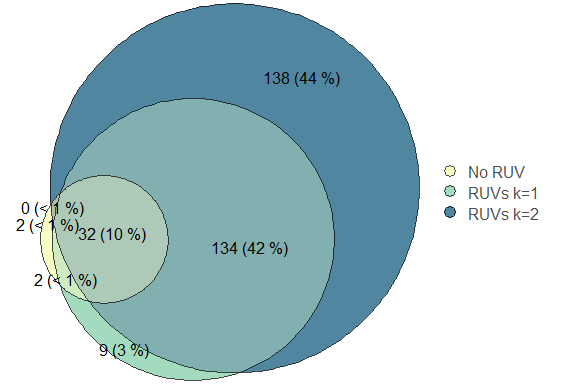

```r
plot(eulerplot, quantities = list(T, type = c("counts", "percent"), fontsize = 12),
     fills = c(carto_pal(7,"BluYl") [1],carto_pal(7,"BluYl") [3], carto_pal(7,"BluYl") [7]),
     adjust_labels = T, alpha = 0.7, legend = T, labels = F)
```

```r
#dev.off()
```

Check how corrections methods affect correlation of metadata with the data. Do it with a simple linear regression

```r
library(PCAtools)
p_list <- set_names(list(rld,rld1.nobatch,rld2.nobatch), nm = c("No RUV", "RUVs k=1", "RUVs k=2")) %>%
  map(~pca(assay(.x), colData(.x), removeVar = 0.1))
```

```
-- removing the lower 10% of variables based on variance
-- removing the lower 10% of variables based on variance
-- removing the lower 10% of variables based on variance
```

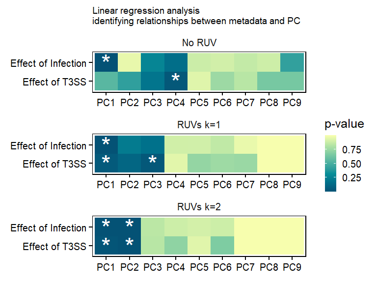

```r
pca_coord_meta_list <- p_list %>%
  map(~.x$rotated) %>%
  map2(list(rld,rld1.nobatch,rld2.nobatch), ~merge(.x,as.data.frame(colData(.y)), by = 0)) %>%
  map(mutate, group = fct_relevel(group, "WT9"))
#Create the lists to store information on the linear model performance
fit_list <- p_list
signi_list <- p_list
#Run the linear model for each PC
for (i in seq_along(pca_coord_meta_list)) {
  pca_coord_meta_df <- pca_coord_meta_list [[i]]
  #Create a fit for each PC
  fit_list [[i]] <- set_names(vector(mode = "list", length = 9),
                              nm = str_c("PC",1:9))
  signi_list [[i]] <- set_names(vector(mode = "list", length = 9),
                              nm = str_c("PC",1:9))
  for (PC in seq_along(fit_list [[i]])) {
    frm <- as.formula(str_c("PC",PC, " ~ group"))
    fit_list [[i]] [[PC]] <- lm(frm, data = pca_coord_meta_df)
    sum_of_fit <- summary(fit_list [[i]] [[PC]])
    signi_list [[i]] [[PC]] <- sum_of_fit$coefficients %>%
      as.data.frame() %>%
      mutate(R_squared = sum_of_fit$r.squared)
  }
}
#Summarise liner model performance and plot the results
signi_list_reduced <- signi_list %>%
  map(~map2(.x,names(.x), ~mutate(.x, PC = .y))) %>%
  map(map, rownames_to_column, var = "coef") %>%
  map(purrr::reduce, bind_rows) %>%
  map2(names(signi_list), ~mutate(.x, RUV = .y)) %>%
  purrr::reduce(bind_rows) %>%
  filter(coef != "(Intercept)") %>%
  dplyr::rename(p = `Pr(>|t|)`) %>%
  mutate(signi = case_when(
    p < 0.05 ~ "yes",
    TRUE ~ "no"
  ))
#Plot the results of regression
ggplot(signi_list_reduced) +
  geom_tile(aes(y=coef,x=PC, fill = p)) +
  geom_text(data = filter(signi_list_reduced, signi == "yes"), aes(y=coef,x=PC),
            label = "*", color = "white", size = 13) +
  facet_wrap(~RUV, nrow = 3, scales = "free") +
  labs(x = element_blank(), y = element_blank(), title = "Linear regression analysis\nidentifying relationships between metadata and PC") +
  scale_y_discrete(labels = c(groupUI9 = "Effect of Infection",groupN9 = "Effect of T3SS")) +
  scale_fill_carto_c(palette = "BluYl", direction = -1, name = "p-value") +
  theme_minimal(base_size = 19) +
  theme(panel.border = element_rect(fill = NA, color = "black"),
        axis.ticks.x = element_line(color = "black"),
        axis.ticks.y = element_line(color = "black"),
        panel.grid.major = element_blank(),
        axis.text = element_text(color = "black"),
        title = element_text(size = 12),
        legend.title = element_text(size = 19))
```

```r
#ggsave(here::here("long_infection_human_reads/long_RNA_library/results/final RUV figures/Linear regression of metadata and PCA with respect to RUV.png"), width = 8,height = 6, dpi = 1080)
```

Finally, just make a quick PCA plot to confirm tighter grouping

```
$`No RUV`

$`RUVs k=1`

$`RUVs k=2`
```

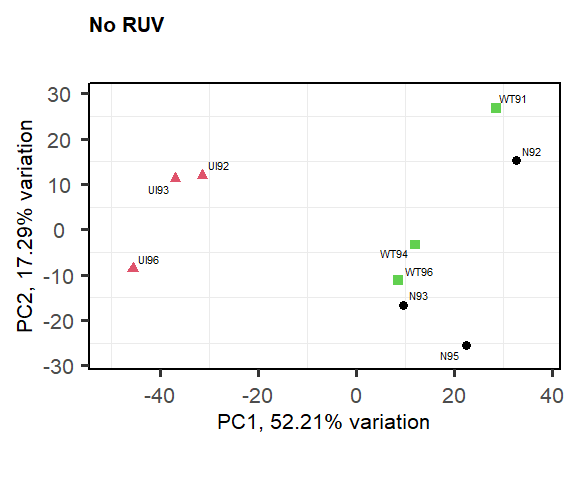

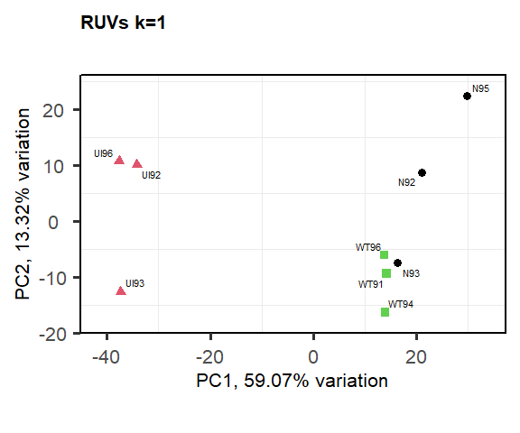

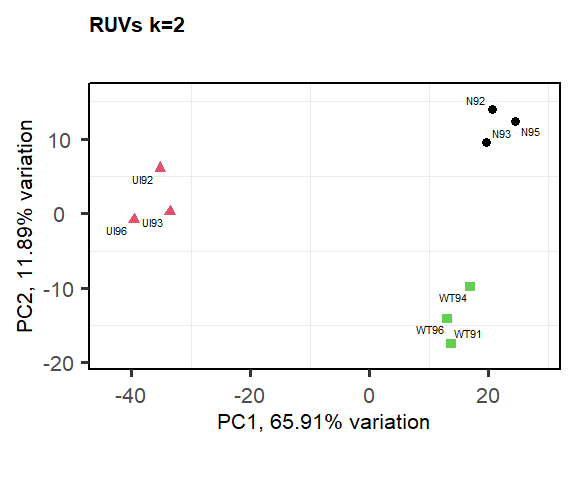

```r
#pdf(here::here("long_infection_human_reads/long_RNA_library/results/final RUV figures/PCAtools biplots with RUV.pdf"), width = 6, height = 5)
coloring_key <- fct_unique(as_factor(set_names(pData$graph_cols, nm = pData$genotype)))
map2(p_list, names(p_list),
      ~biplot(.x, colby = "genotype", shape = "genotype",gridlines.major = FALSE, title = .y,
              colkey = coloring_key))
```

```r
#dev.off()
```

From this it is clear that 2 unwanted factors is better than 1. We get majority of the same DE genes as non-adjusted or 1 factor adjusted objects and better grouping of the samples.